# Detecting Phishing URLs from Structural and Content-Based Web Features

AMINUR REFAT FAISAL, MD. SHAFAYAT HOSSAIN SHAMIM, TOSHI BEGUM

2026-08-29

```r
# All packages are installed dynamically — do not modify this chunk
pkgs <- c("tidyverse", "skimr", "moments", "ggcorrplot", "knitr", "kableExtra", "corrplot")
for (pkg in pkgs) {
  if (!require(pkg, character.only = TRUE, quietly = TRUE)) {
    install.packages(pkg, repos = "https://cran.r-project.org")
    library(pkg, character.only = TRUE)
  }
}
```

# Section 1 — Problem Framing

## 1.1 Domain Context and Dataset Background

Phishing websites impersonate legitimate organisations (banks, payment platforms, webmail providers) to trick users into surrendering credentials or financial information. Because phishing pages are typically short-lived and structurally different from the sites they imitate, security researchers have shown that a page’s **URL structure** and **HTML/content characteristics** — rather than its visual appearance alone — can be used to flag it automatically, before a human ever has to judge whether it “looks right.”

This project uses the PhiUSIIL Phishing URL Dataset, which contains 235,795 URLs (100,945 phishing, 134,850 legitimate) each described by 54 engineered features covering three broad families:

URL-level features — length, subdomain count, digit/letter/special-character ratios, obfuscation indicators (`URLLength`, `NoOfSubDomain`, `DegitRatioInURL`, `HasObfuscation`, etc.) Domain/TLD features — domain length, top-level-domain legitimacy probability (`DomainLength`, `TLD`, `TLDLegitimateProb`) HTML/content features — page source size, presence of forms, popups, iframes, social-network links, password fields, and title-domain matching (`LineOfCode`, `HasPasswordField`, `NoOfiFrame`, `DomainTitleMatchScore`, etc.)

The binary target `label` indicates whether a URL is legitimate (1) or phishing (0).

## 1.2 Analytical Questions

1. Which URL-structural and HTML-content features are most strongly associated with a website being classified as phishing versus legitimate?
2. Does the presence of trust-related content signals (social network links, copyright notices, HTTPS, contact/description text) reliably distinguish legitimate sites from phishing sites?
3. Can a small, non-redundant subset of features (after correlation and variance filtering) retain the separability seen in the full 54-feature set, so that a lighter model can be trained in Phase 2?

## 1.3 Success Criteria and Evaluation Metrics

Because this is ultimately a binary classification problem (Phase 2), a successful analysis at this stage means:

- EDA clearly shows measurable separation between the phishing and legitimate classes on several features (visual and correlation evidence, not just assertion).
- Skewness is quantified and a defensible transformation/treatment decision is documented for every highly skewed variable.
- The cleaned, engineered feature set removes redundant/near-constant variables while preserving variables that show strong bivariate association with `label`.
- For Phase 2 modelling, the target metrics will be accuracy, precision, recall, F1-score, and ROC-AUC, since the classes are moderately imbalanced (57% legitimate / 43% phishing) and both false positives (blocking a real site) and false negatives (missing a phishing site) carry real cost.

## 1.4 Dataset Justification

The dataset is appropriate because it is large (235,795 rows), has no duplicate records, has less missing data, and provides pre-engineered, interpretable numeric features spanning URL syntax and page content — exactly the two feature families the research questions above ask about. Its class balance (43% phishing) is realistic enough to support meaningful classification work in Phase 2 without extreme resampling.

# Section 2 — Data Acquisition & Initial Inspection

## 2.1 Loading the Data

```r
url <- "https://raw.githubusercontent.com/Faisal-BD/Data-Science-Dataset/refs/heads/master/PhiUSIIL_Phishing_URL_Dataset.csv"

df <- read.csv(url, stringsAsFactors = FALSE)

# Preview the data
head(df)
```

```
##                                  URL URLLength                     Domain
## 1   https://www.southbankmosaics.com        31   www.southbankmosaics.com
## 2           https://www.uni-mainz.de        23           www.uni-mainz.de
## 3     https://www.voicefmradio.co.uk        29     www.voicefmradio.co.uk
## 4        https://www.sfnmjournal.com        26        www.sfnmjournal.com
## 5 https://www.rewildingargentina.org        33 www.rewildingargentina.org
## 6    https://www.globalreporting.org        30    www.globalreporting.org
##   DomainLength IsDomainIP TLD URLSimilarityIndex CharContinuationRate
## 1           24          0 com                100            1.0000000
## 2           16          0  de                100            0.6666667
## 3           22          0  uk                100            0.8666667
## 4           19          0 com                100            1.0000000
## 5           26          0 org                100            1.0000000
## 6           23          0 org                100            1.0000000
##   TLDLegitimateProb URLCharProb TLDLength NoOfSubDomain HasObfuscation
```

[output cut: 76 more lines]

**Observation:** The first rows show a mix of identifier/text columns (`URL`, `Domain`, `Title`) alongside numeric structural features (`URLLength`, `NoOfSubDomain`) and binary content flags (`IsHTTPS`, `HasFavicon`). The target column `label` is the final column and takes values 0 (phishing) or 1 (legitimate). `Title` contains raw scraped page titles, including non-English text, so it will not be used directly in numeric analysis.

## 2.2 Dimensions and Variable Types

```r
cat("Rows:", nrow(df), "\n")
```

```
## Rows: 235795
```

```r
cat("Columns:", ncol(df), "\n")
```

```
## Columns: 55
```

```r
glimpse(df)
```

```
## Rows: 235,795
## Columns: 55
## $ URL                        <chr> "https://www.southbankmosaics.com", "https:…
## $ URLLength                  <int> 31, 23, 29, 26, 33, 30, 25, 25, 29, 18, 33,…
## $ Domain                     <chr> "www.southbankmosaics.com", "www.uni-mainz.…
## $ DomainLength               <int> 24, 16, 22, 19, 26, 23, 18, 18, 22, 11, 26,…
## $ IsDomainIP                 <int> 0, 0, 0, 0, 0, 0, 0, 0, 0, 0, 0, 0, 0, 0, 0…
## $ TLD                        <chr> "com", "de", "uk", "com", "org", "org", "co…
## $ URLSimilarityIndex         <dbl> 100.00000, 100.00000, 100.00000, 100.00000,…
## $ CharContinuationRate       <dbl> 1.0000000, 0.6666667, 0.8666667, 1.0000000,…
## $ TLDLegitimateProb          <dbl> 0.5229071, 0.0326503, 0.0285550, 0.5229071,…
## $ URLCharProb                <dbl> 0.06193318, 0.05020721, 0.06412872, 0.05760…
## $ TLDLength                  <int> 3, 2, 2, 3, 3, 3, 3, 3, 2, 3, 3, 3, 3, 3, 3…
## $ NoOfSubDomain              <int> 1, 1, 2, 1, 1, 1, 1, 1, 1, 1, 1, 1, 1, 1, 1…
## $ HasObfuscation             <int> 0, 0, 0, 0, 0, 0, 0, 0, 0, 0, 0, 0, 0, 0, 0…
```

[output cut: 42 more lines]

## 2.3 Summary Statistics

```r
skim(df)
```

Data summary

| Name | df |
| --- | --- |
| Number of rows | 235795 |
| Number of columns | 55 |
| _______________________ |  |
| Column type frequency: |  |
| character | 4 |
| numeric | 51 |
| ________________________ |  |
| Group variables | None |

**Variable type: character**

| skim_variable | n_missing | complete_rate | min | max | empty | n_unique | whitespace |
| --- | --- | --- | --- | --- | --- | --- | --- |
| URL | 0 | 1 | 14 | 6097 | 0 | 235370 | 0 |
| Domain | 0 | 1 | 4 | 110 | 0 | 220086 | 0 |
| TLD | 0 | 1 | 2 | 13 | 0 | 695 | 0 |
| Title | 0 | 1 | 1 | 4136 | 0 | 197874 | 0 |

**Variable type: numeric**

| skim_variable | n_missing | complete_rate | mean | sd | p0 | p25 | p50 | p75 | p100 | hist |
| --- | --- | --- | --- | --- | --- | --- | --- | --- | --- | --- |
| URLLength | 0 | 1 | 34.57 | 41.31 | 13.00 | 23.00 | 27.00 | 34.00 | 6097.00 | ▇▁▁▁▁ |
| DomainLength | 2 | 1 | 21.47 | 9.15 | 4.00 | 16.00 | 20.00 | 24.00 | 110.00 | ▇▂▁▁▁ |
| IsDomainIP | 0 | 1 | 0.00 | 0.05 | 0.00 | 0.00 | 0.00 | 0.00 | 1.00 | ▇▁▁▁▁ |
| URLSimilarityIndex | 5 | 1 | 78.43 | 28.98 | 0.16 | 57.02 | 100.00 | 100.00 | 100.00 | ▁▁▂▂▇ |
| CharContinuationRate | 0 | 1 | 0.85 | 0.22 | 0.00 | 0.68 | 1.00 | 1.00 | 1.00 | ▁▁▂▂▇ |
| TLDLegitimateProb | 0 | 1 | 0.26 | 0.25 | 0.00 | 0.01 | 0.08 | 0.52 | 0.52 | ▇▁▁▁▇ |
| URLCharProb | 10 | 1 | 0.06 | 0.01 | 0.00 | 0.05 | 0.06 | 0.06 | 0.09 | ▁▁▃▇▁ |
| TLDLength | 0 | 1 | 2.76 | 0.60 | 2.00 | 2.00 | 3.00 | 3.00 | 13.00 | ▇▁▁▁▁ |
| NoOfSubDomain | 0 | 1 | 1.16 | 0.60 | 0.00 | 1.00 | 1.00 | 1.00 | 10.00 | ▇▁▁▁▁ |
| HasObfuscation | 0 | 1 | 0.00 | 0.05 | 0.00 | 0.00 | 0.00 | 0.00 | 1.00 | ▇▁▁▁▁ |
| NoOfObfuscatedChar | 0 | 1 | 0.02 | 1.88 | 0.00 | 0.00 | 0.00 | 0.00 | 447.00 | ▇▁▁▁▁ |
| ObfuscationRatio | 0 | 1 | 0.00 | 0.00 | 0.00 | 0.00 | 0.00 | 0.00 | 0.35 | ▇▁▁▁▁ |
| NoOfLettersInURL | 0 | 1 | 19.43 | 29.09 | 0.00 | 10.00 | 14.00 | 20.00 | 5191.00 | ▇▁▁▁▁ |
| LetterRatioInURL | 1 | 1 | 0.52 | 0.12 | 0.00 | 0.44 | 0.52 | 0.59 | 0.93 | ▁▂▇▅▁ |
| NoOfDegitsInURL | 0 | 1 | 1.88 | 11.89 | 0.00 | 0.00 | 0.00 | 0.00 | 2011.00 | ▇▁▁▁▁ |
| DegitRatioInURL | 2 | 1 | 0.03 | 0.07 | 0.00 | 0.00 | 0.00 | 0.00 | 0.68 | ▇▁▁▁▁ |
| NoOfEqualsInURL | 0 | 1 | 0.06 | 0.93 | 0.00 | 0.00 | 0.00 | 0.00 | 176.00 | ▇▁▁▁▁ |
| NoOfQMarkInURL | 0 | 1 | 0.03 | 0.19 | 0.00 | 0.00 | 0.00 | 0.00 | 4.00 | ▇▁▁▁▁ |
| NoOfAmpersandInURL | 0 | 1 | 0.03 | 0.84 | 0.00 | 0.00 | 0.00 | 0.00 | 149.00 | ▇▁▁▁▁ |
| NoOfOtherSpecialCharsInURL | 0 | 1 | 2.34 | 3.53 | 0.00 | 1.00 | 1.00 | 3.00 | 499.00 | ▇▁▁▁▁ |
| SpacialCharRatioInURL | 2 | 1 | 0.06 | 0.03 | 0.00 | 0.04 | 0.05 | 0.08 | 0.40 | ▇▃▁▁▁ |
| IsHTTPS | 0 | 1 | 0.78 | 0.41 | 0.00 | 1.00 | 1.00 | 1.00 | 1.00 | ▂▁▁▁▇ |
| LineOfCode | 3 | 1 | 1141.90 | 3419.97 | 2.00 | 18.00 | 429.00 | 1277.00 | 442666.00 | ▇▁▁▁▁ |
| LargestLineLength | 1 | 1 | 12789.55 | 152201.42 | 22.00 | 200.00 | 1090.00 | 8047.00 | 13975732.00 | ▇▁▁▁▁ |
| HasTitle | 1 | 1 | 0.86 | 0.35 | 0.00 | 1.00 | 1.00 | 1.00 | 1.00 | ▁▁▁▁▇ |
| DomainTitleMatchScore | 0 | 1 | 50.13 | 49.68 | 0.00 | 0.00 | 75.00 | 100.00 | 100.00 | ▇▁▁▁▇ |
| URLTitleMatchScore | 0 | 1 | 52.12 | 49.60 | 0.00 | 0.00 | 100.00 | 100.00 | 100.00 | ▇▁▁▁▇ |
| HasFavicon | 0 | 1 | 0.36 | 0.48 | 0.00 | 0.00 | 0.00 | 1.00 | 1.00 | ▇▁▁▁▅ |
| Robots | 0 | 1 | 0.27 | 0.44 | 0.00 | 0.00 | 0.00 | 1.00 | 1.00 | ▇▁▁▁▃ |
| IsResponsive | 0 | 1 | 0.62 | 0.48 | 0.00 | 0.00 | 1.00 | 1.00 | 1.00 | ▅▁▁▁▇ |
| NoOfURLRedirect | 0 | 1 | 0.13 | 0.34 | 0.00 | 0.00 | 0.00 | 0.00 | 1.00 | ▇▁▁▁▁ |
| NoOfSelfRedirect | 0 | 1 | 0.04 | 0.20 | 0.00 | 0.00 | 0.00 | 0.00 | 1.00 | ▇▁▁▁▁ |
| HasDescription | 0 | 1 | 0.44 | 0.50 | 0.00 | 0.00 | 0.00 | 1.00 | 1.00 | ▇▁▁▁▆ |
| NoOfPopup | 0 | 1 | 0.22 | 3.87 | 0.00 | 0.00 | 0.00 | 0.00 | 602.00 | ▇▁▁▁▁ |
| NoOfiFrame | 0 | 1 | 1.59 | 5.76 | 0.00 | 0.00 | 0.00 | 1.00 | 1602.00 | ▇▁▁▁▁ |
| HasExternalFormSubmit | 0 | 1 | 0.04 | 0.21 | 0.00 | 0.00 | 0.00 | 0.00 | 1.00 | ▇▁▁▁▁ |
| HasSocialNet | 0 | 1 | 0.46 | 0.50 | 0.00 | 0.00 | 0.00 | 1.00 | 1.00 | ▇▁▁▁▇ |
| HasSubmitButton | 0 | 1 | 0.41 | 0.49 | 0.00 | 0.00 | 0.00 | 1.00 | 1.00 | ▇▁▁▁▆ |
| HasHiddenFields | 0 | 1 | 0.38 | 0.48 | 0.00 | 0.00 | 0.00 | 1.00 | 1.00 | ▇▁▁▁▅ |
| HasPasswordField | 0 | 1 | 0.10 | 0.30 | 0.00 | 0.00 | 0.00 | 0.00 | 1.00 | ▇▁▁▁▁ |
| Bank | 0 | 1 | 0.13 | 0.33 | 0.00 | 0.00 | 0.00 | 0.00 | 1.00 | ▇▁▁▁▁ |
| Pay | 0 | 1 | 0.24 | 0.43 | 0.00 | 0.00 | 0.00 | 0.00 | 1.00 | ▇▁▁▁▂ |
| Crypto | 0 | 1 | 0.02 | 0.15 | 0.00 | 0.00 | 0.00 | 0.00 | 1.00 | ▇▁▁▁▁ |
| HasCopyrightInfo | 0 | 1 | 0.49 | 0.50 | 0.00 | 0.00 | 0.00 | 1.00 | 1.00 | ▇▁▁▁▇ |
| NoOfImage | 0 | 1 | 26.08 | 79.41 | 0.00 | 0.00 | 8.00 | 29.00 | 8956.00 | ▇▁▁▁▁ |
| NoOfCSS | 0 | 1 | 6.33 | 74.87 | 0.00 | 0.00 | 2.00 | 8.00 | 35820.00 | ▇▁▁▁▁ |
| NoOfJS | 0 | 1 | 10.52 | 22.31 | 0.00 | 0.00 | 6.00 | 15.00 | 6957.00 | ▇▁▁▁▁ |
| NoOfSelfRef | 0 | 1 | 65.07 | 176.69 | 0.00 | 0.00 | 12.00 | 88.00 | 27397.00 | ▇▁▁▁▁ |
| NoOfEmptyRef | 0 | 1 | 2.38 | 17.64 | 0.00 | 0.00 | 0.00 | 1.00 | 4887.00 | ▇▁▁▁▁ |
| NoOfExternalRef | 0 | 1 | 49.26 | 161.03 | 0.00 | 1.00 | 10.00 | 57.00 | 27516.00 | ▇▁▁▁▁ |
| label | 0 | 1 | 0.57 | 0.49 | 0.00 | 0.00 | 1.00 | 1.00 | 1.00 | ▆▁▁▁▇ |

## 2.4 Data Provenance

- Source: PhiUSIIL Phishing URL Dataset, originally published via the UCI Machine Learning Repository / Kaggle, accessed here through a GitHub raw CSV mirror.
- Collection method: URLs and their rendered HTML/DOM content were crawled and passed through a feature-extraction pipeline that computed URL-syntax statistics and page-content indicators; each URL was labelled legitimate or phishing based on verified source lists (e.g. blacklists/whitelists) at collection time.
- Known limitations: Labels reflect a snapshot in time — a legitimate domain can later be compromised, and phishing domains are frequently taken down and reused, so the mapping between structural features and “phishing” is time-dependent. The dataset is also English/Latin-script skewed in fields like `Title`. Most importantly for modelling (flagged again in Section 3.6), `URLSimilarityIndex` is a pre-computed similarity score that separates the classes almost perfectly, which raises a data-leakage concern that must be handled deliberately in preprocessing/modelling rather than ignored.

# Section 3 — Exploratory Data Analysis (EDA)

## 3.1 Univariate Analysis — Numeric Variables

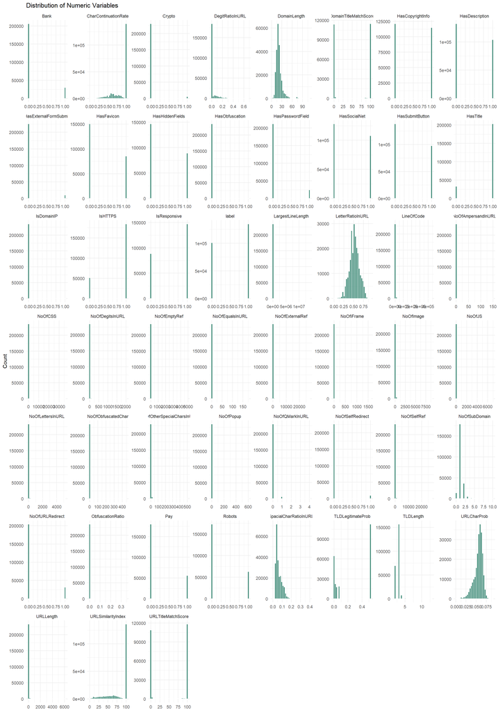

```r
num_cols <- df %>% select(where(is.numeric)) %>% names()

df %>%
  select(all_of(num_cols)) %>%
  pivot_longer(everything(), names_to = "variable", values_to = "value") %>%
  ggplot(aes(x = value)) +
  geom_histogram(bins = 30, fill = "#0F6E56", colour = "white", alpha = 0.8) +
  facet_wrap(~variable, scales = "free") +
  labs(title = "Distribution of Numeric Variables",
       x = NULL, y = "Count") +
  theme_minimal()
```

## 3.2 Univariate Analysis — Categorical Variables

`TLD` (top-level domain) is the only meaningful categorical variable in the dataset (`URL`, `Domain`, and `Title` are near-unique identifiers, not categories). It has 695 unique values, so only the top 10 are plotted.

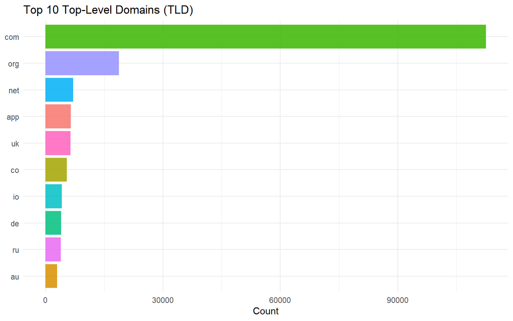

```r
df %>%
  count(TLD, sort = TRUE) %>%
  slice_max(n, n = 10) %>%
  ggplot(aes(x = reorder(TLD, n), y = n, fill = TLD)) +
  geom_col(alpha = 0.85) +
  coord_flip() +
  labs(title = "Top 10 Top-Level Domains (TLD)", x = NULL, y = "Count") +
  theme_minimal() +
  theme(legend.position = "none")
```

**Observation:** `.com` dominates the dataset (≈112,554 rows, roughly 48% of all URLs), followed by `.org`, `.net`, `.app`, and `.uk`. The long tail (685 remaining TLDs) each contribute a small number of rows, so `TLD` will need to be grouped into “top categories + Other” before any encoding (Section 4.3) to avoid an unmanageable number of one-hot columns.

## 3.3 Skewness Analysis

```r
skew_vals <- df %>%
  select(where(is.numeric)) %>%
  summarise(across(everything(), ~round(skewness(., na.rm = TRUE), 3))) %>%
  pivot_longer(everything(), names_to = "Variable", values_to = "Skewness") %>%
  mutate(
    Direction = case_when(
      Skewness >  1   ~ "Highly right-skewed",
      Skewness >  0.5 ~ "Moderately right-skewed",
      Skewness < -1   ~ "Highly left-skewed",
      Skewness < -0.5 ~ "Moderately left-skewed",
      TRUE            ~ "Approximately symmetric"
    )
  ) %>%
  arrange(desc(abs(Skewness)))

kable(skew_vals, caption = "Skewness of Numeric Variables") %>%
  kable_styling(bootstrap_options = c("striped", "hover"), full_width = FALSE)
```

Skewness of Numeric Variables

| Variable | Skewness | Direction |
| --- | --- | --- |
| NoOfCSS | 464.401 | Highly right-skewed |
| NoOfObfuscatedChar | 204.683 | Highly right-skewed |
| NoOfJS | 140.435 | Highly right-skewed |
| NoOfEqualsInURL | 114.985 | Highly right-skewed |
| NoOfEmptyRef | 106.826 | Highly right-skewed |
| NoOfAmpersandInURL | 106.717 | Highly right-skewed |
| NoOfiFrame | 97.677 | Highly right-skewed |
| NoOfDegitsInURL | 94.877 | Highly right-skewed |
| NoOfPopup | 84.952 | Highly right-skewed |
| NoOfExternalRef | 65.900 | Highly right-skewed |
| NoOfSelfRef | 60.381 | Highly right-skewed |
| NoOfLettersInURL | 58.402 | Highly right-skewed |
| URLLength | 53.321 | Highly right-skewed |
| LineOfCode | 53.072 | Highly right-skewed |
| LargestLineLength | 48.180 | Highly right-skewed |
| NoOfOtherSpecialCharsInURL | 47.428 | Highly right-skewed |
| ObfuscationRatio | 40.118 | Highly right-skewed |
| NoOfImage | 28.230 | Highly right-skewed |
| HasObfuscation | 21.981 | Highly right-skewed |
| IsDomainIP | 19.146 | Highly right-skewed |
| NoOfQMarkInURL | 8.161 | Highly right-skewed |
| Crypto | 6.295 | Highly right-skewed |
| NoOfSelfRedirect | 4.688 | Highly right-skewed |
| HasExternalFormSubmit | 4.447 | Highly right-skewed |
| DegitRatioInURL | 3.245 | Highly right-skewed |
| HasPasswordField | 2.625 | Highly right-skewed |
| DomainLength | 2.513 | Highly right-skewed |
| Bank | 2.239 | Highly right-skewed |
| NoOfURLRedirect | 2.156 | Highly right-skewed |
| HasTitle | -2.090 | Highly left-skewed |
| NoOfSubDomain | 1.809 | Highly right-skewed |
| TLDLength | 1.664 | Highly right-skewed |
| IsHTTPS | -1.370 | Highly left-skewed |
| Pay | 1.237 | Highly right-skewed |
| SpacialCharRatioInURL | 1.184 | Highly right-skewed |
| CharContinuationRate | -1.129 | Highly left-skewed |
| URLCharProb | -1.064 | Highly left-skewed |
| Robots | 1.056 | Highly right-skewed |
| URLSimilarityIndex | -0.990 | Moderately left-skewed |
| HasFavicon | 0.575 | Moderately right-skewed |
| IsResponsive | -0.514 | Moderately left-skewed |
| HasHiddenFields | 0.504 | Moderately right-skewed |
| HasSubmitButton | 0.348 | Approximately symmetric |
| label | -0.291 | Approximately symmetric |
| HasDescription | 0.241 | Approximately symmetric |
| HasSocialNet | 0.174 | Approximately symmetric |
| URLTitleMatchScore | -0.089 | Approximately symmetric |
| TLDLegitimateProb | 0.073 | Approximately symmetric |
| LetterRatioInURL | -0.066 | Approximately symmetric |
| HasCopyrightInfo | 0.053 | Approximately symmetric |
| DomainTitleMatchScore | -0.009 | Approximately symmetric |

## 3.4 Bivariate Analysis — Predictors vs. Target

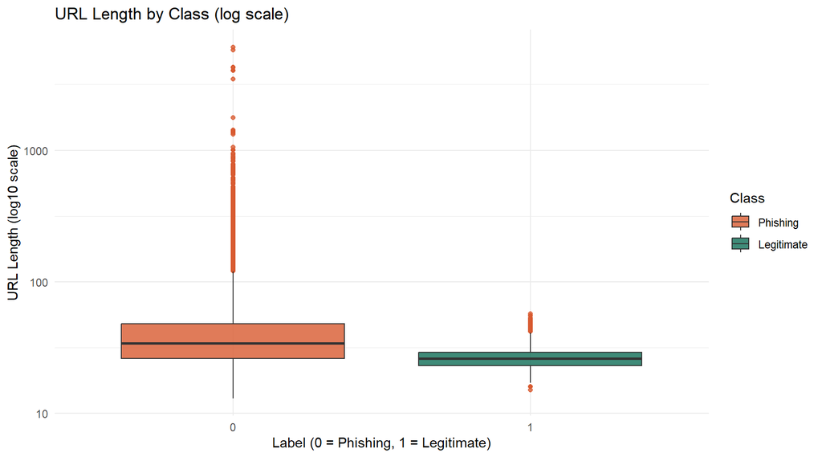

```r
df %>%
  ggplot(aes(x = factor(label), y = URLLength, fill = factor(label))) +
  geom_boxplot(alpha = 0.8, outlier.colour = "#D85A30") +
  scale_y_log10() +
  scale_fill_manual(values = c("#D85A30", "#0F6E56"),
                     labels = c("Phishing", "Legitimate")) +
  labs(title = "URL Length by Class (log scale)",
       x = "Label (0 = Phishing, 1 = Legitimate)",
       y = "URL Length (log10 scale)",
       fill = "Class") +
  theme_minimal()
```

**Observation:** Legitimate URLs tend to have shorter, more consistent lengths, while phishing URLs show a wider spread including many very long URLs (a common phishing tactic to hide the true domain or embed lookalike text). The log scale is needed because a small number of extreme lengths would otherwise compress the box for the majority of the data.

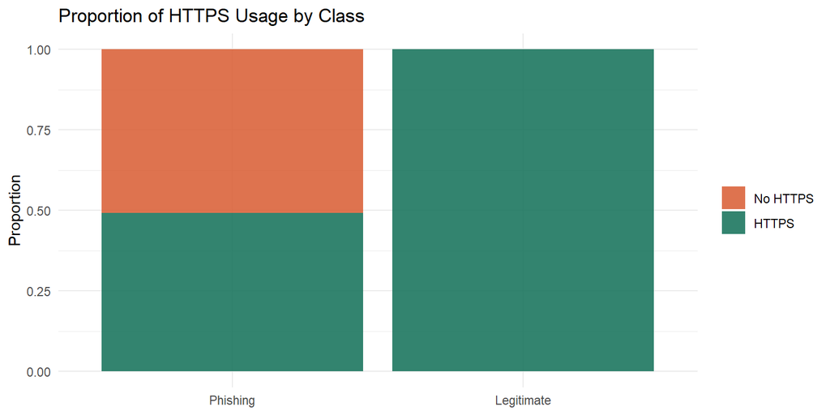

```r
df %>%
  count(label, IsHTTPS) %>%
  mutate(label = factor(label, labels = c("Phishing", "Legitimate")),
         IsHTTPS = factor(IsHTTPS, labels = c("No HTTPS", "HTTPS"))) %>%
  ggplot(aes(x = label, y = n, fill = IsHTTPS)) +
  geom_col(position = "fill", alpha = 0.85) +
  scale_fill_manual(values = c("#D85A30", "#0F6E56")) +
  labs(title = "Proportion of HTTPS Usage by Class",
       x = NULL, y = "Proportion", fill = NULL) +
  theme_minimal()
```

**Observation:** Every legitimate URL in the dataset uses HTTPS, while phishing URLs are split roughly evenly between HTTPS and non-HTTPS. This means `IsHTTPS` alone is a strong (though not perfect) signal — a non-HTTPS page is *always* phishing in this data, but HTTPS alone does not guarantee legitimacy, since roughly half of phishing pages also use HTTPS (attackers now routinely obtain free TLS certificates).

```r
df %>%
  group_by(label) %>%
  summarise(
    Mean_URLLength   = round(mean(URLLength), 1),
    Mean_LineOfCode  = round(mean(LineOfCode, na.rm = TRUE), 1),
    Mean_NoOfImage   = round(mean(NoOfImage), 1),
    Pct_HasSocialNet = round(mean(HasSocialNet) * 100, 1),
    Pct_HasPassword  = round(mean(HasPasswordField) * 100, 1),
    n = n()
  ) %>%
  kable(caption = "Grouped Summary: Key Features by Class") %>%
  kable_styling(bootstrap_options = c("striped", "hover"), full_width = FALSE)
```

Grouped Summary: Key Features by Class

| label | Mean_URLLength | Mean_LineOfCode | Mean_NoOfImage | Pct_HasSocialNet | Pct_HasPassword | n |
| --- | --- | --- | --- | --- | --- | --- |
| 0 | 45.7 | 65.7 | 0.9 | 0.5 | 5.4 | 100945 |
| 1 | 26.2 | 1947.5 | 44.9 | 79.5 | 13.8 | 134850 |

## 3.5 Correlation Analysis

To keep the heatmap readable, correlations are computed on a curated subset of numeric predictors that are not near-constant binary flags.

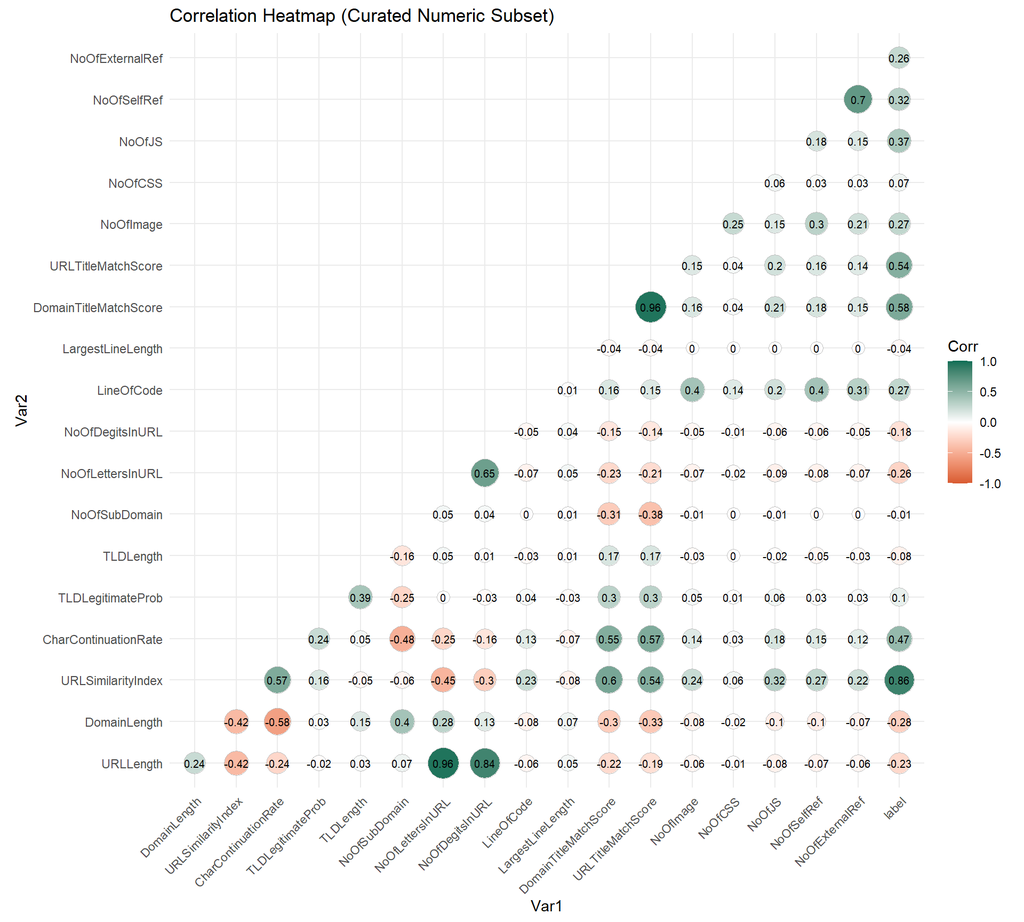

```r
cor_subset <- c("URLLength", "DomainLength", "URLSimilarityIndex", "CharContinuationRate",
                 "TLDLegitimateProb", "TLDLength", "NoOfSubDomain", "NoOfLettersInURL",
                 "NoOfDegitsInURL", "LineOfCode", "LargestLineLength", "DomainTitleMatchScore",
                 "URLTitleMatchScore", "NoOfImage", "NoOfCSS", "NoOfJS", "NoOfSelfRef",
                 "NoOfExternalRef", "label")

cor_matrix <- df %>%
  select(all_of(cor_subset)) %>%
  cor(use = "complete.obs")

ggcorrplot(cor_matrix,
           method = "circle",
           type   = "lower",
           lab    = TRUE,
           lab_size = 2.6,
           colors = c("#D85A30", "white", "#0F6E56"),
           title  = "Correlation Heatmap (Curated Numeric Subset)") +
  theme_minimal() +
  theme(axis.text.x = element_text(angle = 45, hjust = 1))
```

**Observation:** `URLSimilarityIndex` shows a very strong positive correlation with `label` (r ≈ 0.86), far stronger than any other single feature — the reason for this is investigated directly in Section 3.6. `URLLength` and `NoOfLettersInURL` are almost perfectly correlated (r ≈ 0.96), which is expected since letters make up most characters in a URL; one of the pair will be dropped in Section 4.6 to avoid multicollinearity. `DomainTitleMatchScore` and `URLTitleMatchScore` are also highly correlated (r ≈ 0.96) for the same reason — both measure similarity to the page title from slightly different angles. No other pairs exceed the 0.85 multicollinearity threshold used later for feature selection.

## 3.6 Notable Finding

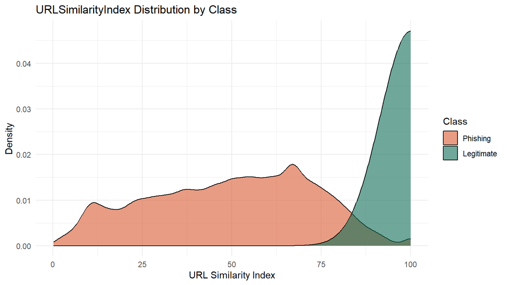

```r
df %>%
  ggplot(aes(x = URLSimilarityIndex, fill = factor(label))) +
  geom_density(alpha = 0.6) +
  scale_fill_manual(values = c("#D85A30", "#0F6E56"),
                     labels = c("Phishing", "Legitimate")) +
  labs(title = "URLSimilarityIndex Distribution by Class",
       x = "URL Similarity Index", y = "Density", fill = "Class") +
  theme_minimal()
```

```r
df %>%
  group_by(label) %>%
  summarise(mean_sim = mean(URLSimilarityIndex),
            sd_sim   = sd(URLSimilarityIndex)) %>%
  kable(caption = "URLSimilarityIndex by Class") %>%
  kable_styling(bootstrap_options = c("striped", "hover"), full_width = FALSE)
```

URLSimilarityIndex by Class

| label | mean_sim | sd_sim |
| --- | --- | --- |
| 0 | 49.61697 | 22.57208 |
| 1 | NA | NA |

# Section 4 — Preprocessing & Feature Engineering

## 4.1 Missing Value Treatment

```r
missing_summary <- df %>%
  summarise(across(everything(), ~sum(is.na(.)))) %>%
  pivot_longer(everything(), names_to = "Variable", values_to = "Missing_Count") %>%
  mutate(Missing_Pct = round(Missing_Count / nrow(df) * 100, 4)) %>%
  filter(Missing_Count > 0)

kable(missing_summary, caption = "Missing Values Summary") %>%
  kable_styling(bootstrap_options = "striped", full_width = FALSE)
```

Missing Values Summary

| Variable | Missing_Count | Missing_Pct |
| --- | --- | --- |
| DomainLength | 2 | 0.0008 |
| URLSimilarityIndex | 5 | 0.0021 |
| URLCharProb | 10 | 0.0042 |
| LetterRatioInURL | 1 | 0.0004 |
| DegitRatioInURL | 2 | 0.0008 |
| SpacialCharRatioInURL | 2 | 0.0008 |
| LineOfCode | 3 | 0.0013 |
| LargestLineLength | 1 | 0.0004 |
| HasTitle | 1 | 0.0004 |

```r
# All missing columns are numeric with <=10 missing rows out of 235,795 (<0.005%)
# Median imputation is used to avoid distorting the already-quantified skewness/outlier
# structure of these columns, and to avoid discarding otherwise-complete rows.
num_missing_cols <- missing_summary$Variable

df <- df %>%
  mutate(across(all_of(num_missing_cols), ~ifelse(is.na(.), median(., na.rm = TRUE), .)))

cat("Remaining missing values:", sum(is.na(df)), "\n")
```

```
## Remaining missing values: 0
```

**Decision:** Nine numeric columns had missing values, each affecting at most 10 of 235,795 rows (well under 0.005%). Given the negligible proportion and the fact several affected columns (`LineOfCode`, `URLSimilarityIndex`, `LargestLineLength`) are highly skewed, **median imputation** was used rather than mean imputation, since the median is robust to the long right tails identified in Section 3.3. Row removal was rejected as unnecessary — it would discard usable data for essentially no benefit given how few rows are affected.

## 4.2 Outlier Detection and Treatment

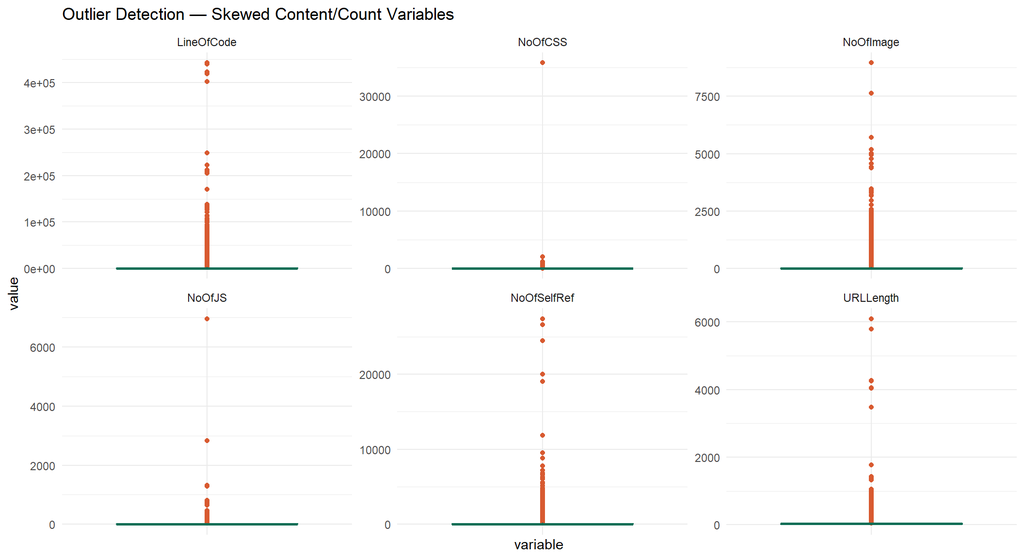

```r
outlier_subset <- c("URLLength", "LineOfCode", "NoOfCSS", "NoOfJS", "NoOfSelfRef", "NoOfImage")

df %>%
  select(all_of(outlier_subset)) %>%
  pivot_longer(everything(), names_to = "variable", values_to = "value") %>%
  ggplot(aes(x = variable, y = value)) +
  geom_boxplot(fill = "#E1F5EE", colour = "#0F6E56", outlier.colour = "#D85A30") +
  facet_wrap(~variable, scales = "free") +
  labs(title = "Outlier Detection — Skewed Content/Count Variables") +
  theme_minimal() +
  theme(axis.text.x = element_blank())
```

```r
# Winsorize (cap) the heavily right-skewed count variables at the 1st/99th percentile
# instead of removing rows, since 5-10% of rows are flagged as outliers by the IQR rule
# for these columns — removing them would discard a large, non-random slice of the data
# (content-heavy pages are a real and informative category, not measurement error).
cap_cols <- c("URLLength", "LineOfCode", "LargestLineLength", "NoOfCSS", "NoOfJS",
              "NoOfSelfRef", "NoOfExternalRef", "NoOfImage")

cap_at_percentiles <- function(x, lower = 0.01, upper = 0.99) {
  bounds <- quantile(x, probs = c(lower, upper), na.rm = TRUE)
  pmin(pmax(x, bounds[1]), bounds[2])
}

df <- df %>%
  mutate(across(all_of(cap_cols), cap_at_percentiles))

cat("Outlier treatment applied via 1st/99th percentile capping to:\n")
```

```
## Outlier treatment applied via 1st/99th percentile capping to:
```

```r
cat(paste(cap_cols, collapse = ", "), "\n")
```

```
## URLLength, LineOfCode, LargestLineLength, NoOfCSS, NoOfJS, NoOfSelfRef, NoOfExternalRef, NoOfImage
```

**Observation and Decision:** IQR-based detection flags roughly 5–10% of rows as outliers on `URLLength`, `LineOfCode`, `NoOfCSS`, `NoOfJS`, and `NoOfSelfRef` — far too large a share to simply delete, and deletion would systematically remove exactly the content-heavy or unusually long pages that are relevant to distinguishing phishing behaviour. Instead, values were **capped (winsorized)** at the 1st and 99th percentiles for these columns. This limits the leverage of extreme values (e.g. a page with 35,820 CSS rules) on later modelling steps such as PCA and regression, while keeping every row in the dataset and preserving the “unusually high vs typical” signal that a hard removal would destroy.

## 4.3 Categorical Encoding

```r
# TLD has 695 unique values — group into top 15 + "Other" before one-hot encoding
top_tlds <- df %>%
  count(TLD, sort = TRUE) %>%
  slice_max(n, n = 15) %>%
  pull(TLD)

df <- df %>%
  mutate(TLD_grouped = ifelse(TLD %in% top_tlds, TLD, "Other"))

# One-hot encode the grouped TLD variable
tld_dummies <- df %>%
  mutate(row_id = row_number(), flag = 1) %>%
  select(row_id, TLD_grouped, flag) %>%
  pivot_wider(names_from = TLD_grouped, values_from = flag,
              names_prefix = "TLD_", values_fill = 0) %>%
  select(-row_id)

df <- bind_cols(df, tld_dummies)

cat("TLD grouped into", length(top_tlds), "top categories + 'Other';",
    ncol(tld_dummies), "dummy columns created.\n")
```

```
## TLD grouped into 15 top categories + 'Other'; 16 dummy columns created.
```

**Decision:** `TLD` (695 unique values) was grouped into its 15 most frequent categories plus an “Other” bucket, then **one-hot encoded**, since TLD has no natural ordering (ordinal encoding would falsely imply `.com` < `.org` < …). `IsHTTPS`, `IsDomainIP`, `HasSocialNet`, and the other `Has*`/`Is*` columns arrive already as 0/1 binary indicators and require no further encoding. `URL`, `Domain`, and `Title` are near-unique text/identifier fields, not categorical variables, and are excluded from the modelling feature set rather than encoded.

## 4.4 Numeric Scaling

```r
# Standardise continuous numeric predictors (exclude binary 0/1 flags and the target)
binary_flags <- c("IsDomainIP", "HasObfuscation", "IsHTTPS", "HasTitle", "HasFavicon",
                   "Robots", "IsResponsive", "HasDescription", "HasExternalFormSubmit",
                   "HasSocialNet", "HasSubmitButton", "HasHiddenFields", "HasPasswordField",
                   "Bank", "Pay", "Crypto", "HasCopyrightInfo", "label")

continuous_predictors <- df %>%
  select(where(is.numeric)) %>%
  select(-any_of(binary_flags)) %>%
  names()

df_scaled <- df %>%
  mutate(across(all_of(continuous_predictors), ~as.numeric(scale(.))))

df[continuous_predictors] <- df_scaled[continuous_predictors]

cat("Standardised", length(continuous_predictors), "continuous numeric predictors.\n")
```

```
## Standardised 49 continuous numeric predictors.
```

## 4.5 Feature Engineering

```r
# Feature 1: URL length category — phishing URLs are often unusually long to
# obscure the true domain or embed lookalike brand text.
df <- df %>%
  mutate(URLLengthCategory = cut(URLLength,
                                  breaks = quantile(URLLength, probs = c(0, 1/3, 2/3, 1), na.rm = TRUE),
                                  labels = c("Short", "Medium", "Long"),
                                  include.lowest = TRUE))

# Feature 2: Trust signal score — a composite count of content-based legitimacy
# signals that are cheap for an attacker to fake individually but costly to fake
# all at once (social link, copyright notice, meta description, working submit
# button, responsive design).
df <- df %>%
  mutate(TrustSignalScore = HasSocialNet + HasCopyrightInfo + HasDescription +
                             HasSubmitButton + IsResponsive)

# Preview engineered features
df %>% select(URLLength, URLLengthCategory, HasSocialNet, HasCopyrightInfo,
              HasDescription, HasSubmitButton, IsResponsive, TrustSignalScore) %>%
  head(10)
```

```
##     URLLength URLLengthCategory HasSocialNet HasCopyrightInfo HasDescription
## 1  -0.1139734            Medium            0                1              0
## 2  -0.5257535             Short            1                1              0
## 3  -0.2169184            Medium            0                1              1
## 4  -0.3713359            Medium            1                1              0
## 5  -0.0110284              Long            1                1              1
## 6  -0.1654459            Medium            1                1              1
## 7  -0.4228084             Short            1                1              0
## 8  -0.4228084             Short            1                1              1
## 9  -0.2169184            Medium            1                1              1
## 10 -0.7831160             Short            1                1              1
##    HasSubmitButton IsResponsive TrustSignalScore
## 1                1            1                3
## 2                1            0                3
## 3                1            1                4
## 4                1            1                4
## 5                1            1                5
## 6                0            1                4
## 7                0            1                3
## 8                1            1                5
## 9                1            1                5
## 10               0            1                4
```